# Analysis of Tamil psych verbs word order

# Loading and updating the non-psych verbs dataset

#### 1. Loading the annotation file into R

```r
tamil.non.psych.verb.df <- read.csv2(file.choose())
```

#### 2. Removing the unwanted columns

```r
tamil.non.psych.verb.df <- select(tamil.non.psych.verb.df, -c(Sentence, Case_of_subject_inTamil, Case_of_object_inTamil, Psych))
```

#### 3. Removing white spaces from the column values

```r
tamil.non.psych.verb.df <- mutate_if(tamil.non.psych.verb.df, is.character, str_trim)
```

#### 4. Updating the column values of ‘Case_of_object’ column

```r
tamil.non.psych.verb.df <- mutate(tamil.non.psych.verb.df, Case_of_object = replace(Case_of_object, Case_of_object == 'accusative (phrasal)','accusative'))

tamil.non.psych.verb.df <- mutate(tamil.non.psych.verb.df, Case_of_object = replace(Case_of_object, Case_of_object == 'locative (phrasal)','locative'))

tamil.non.psych.verb.df <- mutate(tamil.non.psych.verb.df, Case_of_object = replace(Case_of_object, Case_of_object %in% c("special verbal participle 'endru'", "special verbal participle 'aaga'", "special verbal participle 'patri'","special verbal participle 'ena'"),'special verbal participle'))
```

```r
table (tamil.non.psych.verb.df$Case_of_object)
```

```
##
##                accusative                  locative special verbal participle
##                       338                        41                        20
```

#### 5. Converting all the character columns as well as ID column into factors

```r
tamil.non.psych.verb.df <- tamil.non.psych.verb.df %>% mutate_if(is.character, as.factor) %>% mutate_at(c('ID'), as.factor)
```

#### 6. Converting integer column values into logarithmic values by adding new columns

```r
tamil.non.psych.verb.df <- mutate(tamil.non.psych.verb.df, log_syllable_subject = log(Syllable_of_subject), log_syllable_object = log(Syllable_of_object))
```

#### 7. Checking the structure of the dataframe

```r
str(tamil.non.psych.verb.df)
```

```
## 'data.frame':    399 obs. of  17 variables:
##  $ ID                  : Factor w/ 399 levels "1","2","3","4",..: 1 2 3 4 5 6 7 8 9 10 ...
##  $ Verb                : Factor w/ 2 levels "தேடு (thaedu - to search)",..: 2 2 2 2 2 2 2 2 2 2 ...
##  $ EO...ES             : Factor w/ 1 level "none": 1 1 1 1 1 1 1 1 1 1 ...
##  $ Word_order          : Factor w/ 2 levels "OSV","SOV": 2 2 1 1 1 2 2 2 2 2 ...
##  $ Phrasal_subject     : Factor w/ 2 levels "no","yes": 1 2 1 1 1 2 2 2 1 2 ...
##  $ Clausal_object      : Factor w/ 2 levels "no","yes": 1 1 1 1 1 1 1 1 1 1 ...
##  $ Case_of_subject     : Factor w/ 2 levels "nominative","nominative (phrasal)": 1 2 1 1 1 2 1 2 1 2 ...
##  $ Case_of_object      : Factor w/ 3 levels "accusative","locative",..: 1 1 1 1 1 1 2 2 3 1 ...
##  $ Animacy_of_subject  : Factor w/ 2 levels "animate","rational": 2 2 2 2 2 2 2 2 2 2 ...
##  $ Animacy_of_object   : Factor w/ 4 levels "animate","inanimate",..: 2 2 2 2 2 2 2 2 3 2 ...
##  $ Pronoun_subject     : Factor w/ 2 levels "no","yes": 1 1 2 2 2 1 1 1 2 1 ...
##  $ Pronoun_object      : Factor w/ 2 levels "no","yes": 1 1 1 1 1 1 1 1 1 1 ...
##  $ Syllable_of_subject : int  1 3 1 1 1 9 3 2 1 2 ...
##  $ Syllable_of_object  : int  1 3 6 3 1 2 2 1 6 1 ...
##  $ Focus               : Factor w/ 5 levels "none","object (emphasized)",..: 1 4 2 2 3 1 1 1 1 1 ...
##  $ log_syllable_subject: num  0 1.1 0 0 0 ...
##  $ log_syllable_object : num  0 1.1 1.79 1.1 0 ...
```

```r
summary (tamil.non.psych.verb.df)
```

```
##        ID                                   Verb     EO...ES    Word_order
##  1      :  1   தேடு (thaedu - to search)      :199   none:399   OSV:111
##  2      :  1   படி (padi - to read / to study):200              SOV:288
##  3      :  1
##  4      :  1
##  5      :  1
##  6      :  1
##  (Other):393
##  Phrasal_subject Clausal_object             Case_of_subject
##  no :250         no :391        nominative          :253
##  yes:149         yes:  8        nominative (phrasal):146
##
##
##
##
##
##                    Case_of_object Animacy_of_subject Animacy_of_object
##  accusative               :338    animate :  7       animate  :  6
##  locative                 : 41    rational:392       inanimate:272
##  special verbal participle: 20                       none     : 21
##                                                      rational :100
##
##
##
##  Pronoun_subject Pronoun_object Syllable_of_subject Syllable_of_object
##  no :268         no :387        Min.   : 1.000      Min.   : 1.000
##  yes:131         yes: 12        1st Qu.: 1.000      1st Qu.: 2.000
##                                 Median : 1.000      Median : 3.000
##                                 Mean   : 2.391      Mean   : 3.912
##                                 3rd Qu.: 3.000      3rd Qu.: 5.000
##                                 Max.   :17.000      Max.   :19.000
##
##                                        Focus     log_syllable_subject
##  none                                     :279   Min.   :0.0000
##  object (emphasized)                      : 27   1st Qu.:0.0000
##  subject                                  : 72   Median :0.0000
##  subject (emphasized)                     : 18   Mean   :0.5378
##  subject (emphasized), object (emphasized):  3   3rd Qu.:1.0986
##                                                  Max.   :2.8332
##
##  log_syllable_object
##  Min.   :0.0000
##  1st Qu.:0.6931
##  Median :1.0986
##  Mean   :1.0894
##  3rd Qu.:1.6094
##  Max.   :2.9444
##
```

#### 8. Checking the no. of data for SOV and OSV order

```r
table (tamil.non.psych.verb.df$Word_order)
```

```
##
## OSV SOV
## 111 288
```

#### 9. Displaying the word order frequency in bar chart

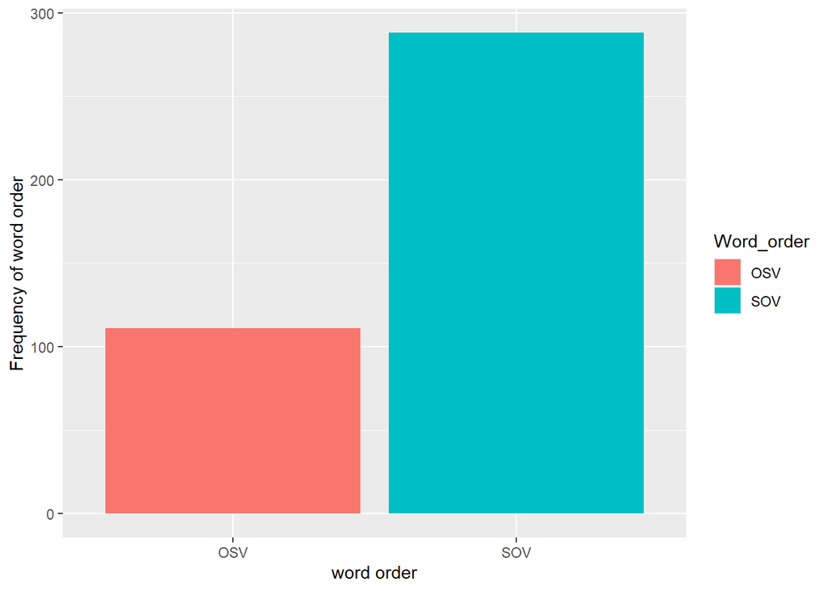

```r
ggplot(tamil.non.psych.verb.df, aes(x = Word_order)) +
  geom_bar(stat = "count", aes(fill = Word_order)) +
  labs(x = "word order", y = "Frequency of word order")
```

#### 10. Checking the word order against the syllabe of subject and object

```r
tamil.non.psych.verb.df %>% group_by(Word_order) %>% summarise(across(c(Syllable_of_subject, Syllable_of_object), mean))
```

```
## # A tibble: 2 × 3
##   Word_order Syllable_of_subject Syllable_of_object
##   <fct>                    <dbl>              <dbl>
## 1 OSV                       1.57               5.51
## 2 SOV                       2.71               3.30
```

#### 11. Displaying the count of word order against the focus in bar chart

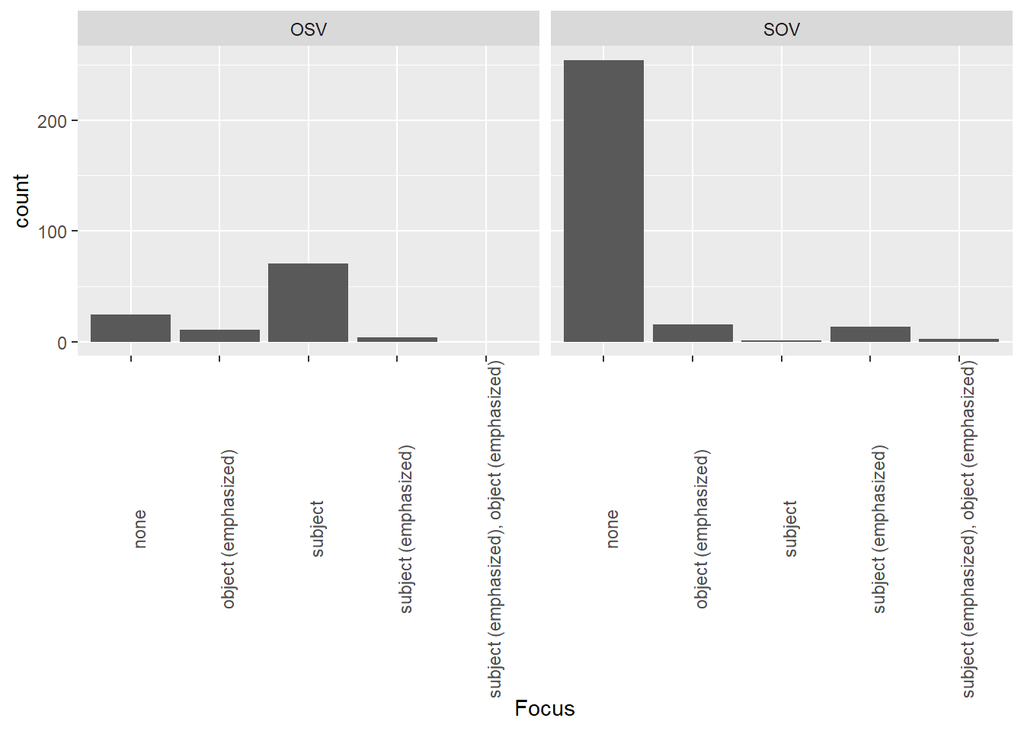

```r
ggplot(tamil.non.psych.verb.df, aes(x = Focus)) +
       geom_bar(stat = "count") +
   facet_wrap(~Word_order) +
  labs(x = "Focus", y = "count") +
    theme(axis.text.x = element_text(angle = 90))
```

# Model 3: GLMM for non-psych verbs

### Creating model 3

```r
tamil.non.psych.verb.glmm <- glmer(Word_order ~ Case_of_subject + Case_of_object + log_syllable_subject + log_syllable_object + Focus + (1 | Verb), family ="binomial", data = tamil.non.psych.verb.df, nAGQ = 0)
```

```r
summary (tamil.non.psych.verb.glmm)
```

```
## Generalized linear mixed model fit by maximum likelihood (Adaptive
##   Gauss-Hermite Quadrature, nAGQ = 0) [glmerMod]
##  Family: binomial  ( logit )
## Formula:
## Word_order ~ Case_of_subject + Case_of_object + log_syllable_subject +
##     log_syllable_object + Focus + (1 | Verb)
##    Data: tamil.non.psych.verb.df
##
##      AIC      BIC   logLik deviance df.resid
##    201.0    244.8    -89.5    179.0      388
##
## Scaled residuals:
##      Min       1Q   Median       3Q      Max
## -18.1668  -0.0337   0.1138   0.2713  16.5984
##
## Random effects:
##  Groups Name        Variance Std.Dev.
##  Verb   (Intercept) 0.21     0.4582
## Number of obs: 399, groups:  Verb, 2
##
## Fixed effects:
##                                                 Estimate Std. Error z value
## (Intercept)                                       5.4100     0.8247   6.560
## Case_of_subjectnominative (phrasal)              -1.1404     0.7992  -1.427
## Case_of_objectlocative                            0.3240     0.6617   0.490
## Case_of_objectspecial verbal participle           0.9019     0.7873   1.145
## log_syllable_subject                              0.7087     0.5565   1.273
## log_syllable_object                              -2.0964     0.3651  -5.742
## Focusobject (emphasized)                         -2.3769     0.5856  -4.059
## Focussubject                                     -8.0438     1.1814  -6.809
## Focussubject (emphasized)                        -1.3725     0.7109  -1.931
## Focussubject (emphasized), object (emphasized)   14.2805  1278.7390   0.011
##                                                        Pr(>|z|)
## (Intercept)                                    0.00000000005381 ***
## Case_of_subjectnominative (phrasal)                      0.1536
## Case_of_objectlocative                                   0.6244
## Case_of_objectspecial verbal participle                  0.2520
## log_syllable_subject                                     0.2029
## log_syllable_object                            0.00000000937918 ***
## Focusobject (emphasized)                       0.00004927073033 ***
```

[output cut: 12 more lines]

```
## lg_syllbl_b  -0.852  0.189  0.018 -0.183 -0.021
## Fcsb(mphszd) -0.382 -0.023 -0.291 -0.041  0.114       0.321
## Focussubjct  -0.442  0.130 -0.036 -0.061 -0.024       0.440       0.226
## Fcss(mphszd) -0.306  0.060  0.036 -0.016 -0.026       0.249       0.213
## F(mphs),o()   0.000  0.000  0.000  0.000  0.000       0.000       0.000
##              Fcssbj Fcss(mphszd)
## Cs_f_(phrs)
## Cs_f_bjctlc
## Cs_f_bjctvp
## lg_syllbl_s
## lg_syllbl_b
## Fcsb(mphszd)
## Focussubjct
## Fcss(mphszd)  0.167
## F(mphs),o()   0.000  0.000
```

Calculating the probabilities of SOV and OSV for non-psych verbs

```r
print ("Probability of SOV order with reference levels")
```

```
## [1] "Probability of SOV order with reference levels"
```

```r
plogis(5.4100)
```

```
## [1] 0.9955483
```

```r
print ("Probability of OSV order with reference levels")
```

```
## [1] "Probability of OSV order with reference levels"
```

```r
1-plogis(5.4100)
```

```
## [1] 0.004451734
```

### Plotting the predictions of model 3 using ggplot

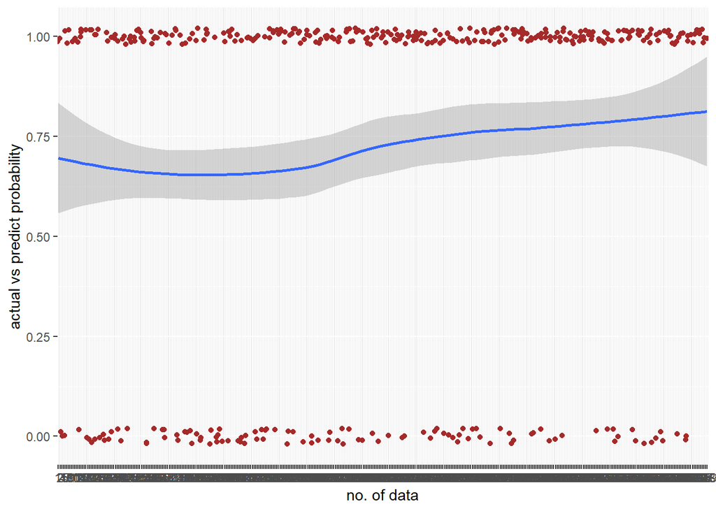

```r
tamil.non.psych.verb.df <- mutate(tamil.non.psych.verb.df, Word_order1 = ifelse(Word_order =='SOV', 1, 0))

tamil.non.psych.verb.df$pred <- predict(tamil.non.psych.verb.glmm, type = "response")


ggplot(tamil.non.psych.verb.df, aes(x = ID, y = Word_order1, group = 1)) +
  geom_jitter(width = 1, height = 0.02, color = "brown", show.legend = FALSE) +
  geom_smooth(aes(y=pred)) +
  labs(x = "no. of data", y = "actual vs predict probability")
```

Model 3 shows that average probability of SOV is above 60% !

### Evaluation of model 3

```r
print ("C value with random effect")
```

```
## [1] "C value with random effect"
```

```r
somers2(tamil.non.psych.verb.df$pred, tamil.non.psych.verb.df$Word_order1)
```

```
##           C         Dxy           n     Missing
##   0.9581926   0.9163851 399.0000000   0.0000000
```